# term1_to-share-Copy1

jupyternotebookで書いたものです。jupyternotebookにアップロードして開いてもらうと見やすいと思います。

↓閲覧用にhtmlに変換している。コードとは関係ない。

```python
!ipython nbconvert term1_to-share-Copy1.ipynb --to html
```

```
[TerminalIPythonApp] WARNING | Subcommand `ipython nbconvert` is deprecated and will be removed in future versions.
[TerminalIPythonApp] WARNING | You likely want to use `jupyter nbconvert` in the future
[NbConvertApp] Converting notebook term1_to-share-Copy1.ipynb to html
[NbConvertApp] Writing 945678 bytes to term1_to-share-Copy1.html
```

### ＜全体の流れ＞

「1ヶ月前の売上個数」の特徴量を作りたかったので、一度2019年11月の売上個数を予測させ、その結果を学習データに含めてから2019年12月の売上個数を予測させた。2回の売上個数の予測は両方とも以下のような流れで行った（少し違うところもある）。  
・データ読み込み  
・外れ値を除外（思い返せば商品価格を説明変数に含めていないのに商品価格を参照して除外したのは良かったのか？）  
・年、月、月ブロックなど時間の特徴を作る  
・目的変数（売上個数）を学習に使える形でまとめる  
・concat, mergeでデータを繋げながら説明変数（売上個数以外）を増やす  
・学習させるためにデータを数値化する（labelencoderなどで）  
・見栄えのためにカラムの並べ替え、renameをする（グラフ化するとき英語だと文字化けしないし）  
・データを分割し、モデルを構築して学習させる  
・テストデータを入れて予測させ、結果が負のものは0にする

2019年12月の方は2つのモデルに予測をさせ、その平均をとってからファイル化した。

##### 学習に使用した特徴量

年、月、店舗ID、店舗規模、商品ID、大カテゴリ名、小カテゴリ名、1ヶ月前の売り上げ、12ヶ月前の売り上げ

```python
#必要なデータのダウンロード
import pandas as pd
shistory = pd.read_csv('./sales_data/sales_history.csv')
test = pd.read_csv('./sales_data/test.csv')
sample = pd.read_csv('./sales_data/sample_submission.csv')
category_name = pd.read_csv('./sales_data/category_names.csv')
item_category = pd.read_csv('./sales_data/item_categories.csv')
```

```python
#初めてxgboostを使う場合は実行
pip install xgboost
```

```python
#import
import numpy as np
from itertools import product
import xgboost as xgb
from matplotlib import pyplot as plt
%matplotlib inline
import seaborn as sns
```

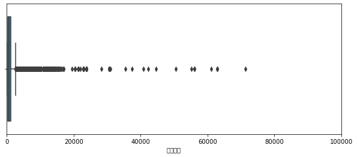

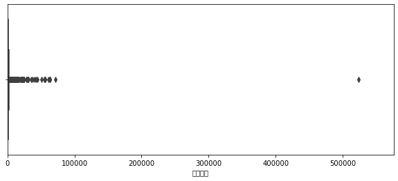

```python
#商品価格の分布をみる
plt.figure(figsize=(10,4))
plt.xlim(-100, 100000)
sns.boxplot(x=shistory.商品価格)

plt.figure(figsize=(10,4))
plt.xlim(shistory.商品価格.min(), shistory.商品価格.max()*1.1)
sns.boxplot(x=shistory.商品価格)
```

```python
#商品価格が一定値以上の行を削除。20000にしたのはなんとなく。
shistory = shistory[shistory.商品価格<20000]
shistory = shistory[shistory.商品価格!=0]
shistory
```

|  | 日付 | 店舗ID | 商品ID | 商品価格 | 売上個数 |
| --- | --- | --- | --- | --- | --- |
| 0 | 2018-01-01 | 9 | 1000001 | 420 | 1.0 |
| 1 | 2018-01-01 | 6 | 1000001 | 420 | 1.0 |
| 2 | 2018-01-01 | 10 | 1000001 | 420 | 1.0 |
| 3 | 2018-01-01 | 0 | 1000017 | 250 | 1.0 |
| 4 | 2018-01-01 | 1 | 1000017 | 250 | 1.0 |
| ... | ... | ... | ... | ... | ... |
| 1119565 | 2019-10-31 | 8 | 3400006 | 2700 | 1.0 |
| 1119566 | 2019-10-31 | 7 | 3400009 | 1020 | 1.0 |
| 1119567 | 2019-10-31 | 7 | 3400012 | 510 | 1.0 |
| 1119568 | 2019-10-31 | 4 | 3500001 | 340 | 1.0 |
| 1119569 | 2019-10-31 | 13 | 3500004 | 420 | 1.0 |

1117162 rows × 5 columns

```python
# 「日付」カラムの文字列から、「年」「月」の情報を抽出する
shistory['年'] = shistory['日付'].apply(lambda x: x.split('-')[0])
shistory['月'] = shistory['日付'].apply(lambda x: x.split('-')[1])
```

```python
# 「年」と「月」の全組み合わせを作成する
gp_time = shistory.groupby(['年', '月']).count().reset_index()[['年', '月']]
gp_time

# カラム名「月ブロック」として、通し番号をつける
gp_time['月ブロック'] = list(range(len(gp_time)))

# testデータ用に、評価対象期間である2019年11月(月ブロック: 22)のレコードを追加する
gp_time = gp_time.append({
    '月ブロック': 22,
    '年': '2019',
    '月': '11'
}, ignore_index=True)

# 「月ブロック」カラムをsalesに統合する
shistory = pd.merge(shistory, gp_time, on=['年', '月'], how='left')
shistory
```

|  | 日付 | 店舗ID | 商品ID | 商品価格 | 売上個数 | 年 | 月 | 月ブロック |
| --- | --- | --- | --- | --- | --- | --- | --- | --- |
| 0 | 2018-01-01 | 9 | 1000001 | 420 | 1.0 | 2018 | 01 | 0 |
| 1 | 2018-01-01 | 6 | 1000001 | 420 | 1.0 | 2018 | 01 | 0 |
| 2 | 2018-01-01 | 10 | 1000001 | 420 | 1.0 | 2018 | 01 | 0 |
| 3 | 2018-01-01 | 0 | 1000017 | 250 | 1.0 | 2018 | 01 | 0 |
| 4 | 2018-01-01 | 1 | 1000017 | 250 | 1.0 | 2018 | 01 | 0 |
| ... | ... | ... | ... | ... | ... | ... | ... | ... |
| 1117157 | 2019-10-31 | 8 | 3400006 | 2700 | 1.0 | 2019 | 10 | 21 |
| 1117158 | 2019-10-31 | 7 | 3400009 | 1020 | 1.0 | 2019 | 10 | 21 |
| 1117159 | 2019-10-31 | 7 | 3400012 | 510 | 1.0 | 2019 | 10 | 21 |
| 1117160 | 2019-10-31 | 4 | 3500001 | 340 | 1.0 | 2019 | 10 | 21 |
| 1117161 | 2019-10-31 | 13 | 3500004 | 420 | 1.0 | 2019 | 10 | 21 |

1117162 rows × 8 columns

```python
# 「月ブロック」「商品ID」「店舗ID」でグルーピングし、売上個数の合計を取る
gp_month = shistory.groupby(['月ブロック',  '商品ID', '店舗ID']).agg({'売上個数': np.sum}).reset_index()
gp_month
```

|  | 月ブロック | 商品ID | 店舗ID | 売上個数 |
| --- | --- | --- | --- | --- |
| 0 | 0 | 1000001 | 0 | 6.0 |
| 1 | 0 | 1000001 | 1 | 2.0 |
| 2 | 0 | 1000001 | 2 | 1.0 |
| 3 | 0 | 1000001 | 3 | 2.0 |
| 4 | 0 | 1000001 | 5 | 2.0 |
| ... | ... | ... | ... | ... |
| 494524 | 21 | 3500070 | 16 | 1.0 |
| 494525 | 21 | 3500071 | 13 | 1.0 |
| 494526 | 21 | 3500072 | 2 | 1.0 |
| 494527 | 21 | 3500072 | 16 | 1.0 |
| 494528 | 21 | 3500073 | 17 | 1.0 |

494529 rows × 4 columns

```python
all_combination = []

# '月'、'商品ID'、 '店舗ID'の全組み合わせを作成する
columns = ['月ブロック', '商品ID', '店舗ID']

for i in range(22):
    train_block = shistory[shistory['月ブロック']==i]
    all_combination.append(np.array(list(product([i], train_block['商品ID'].unique(), train_block['店舗ID'].unique()))))

all_combination = pd.DataFrame(np.vstack(all_combination), columns=columns)
all_combination.sort_values(columns, inplace=True)

print(all_combination.info())
all_combination
```

```
<class 'pandas.core.frame.DataFrame'>
Int64Index: 1647486 entries, 3 to 1643253
Data columns (total 3 columns):
 #   Column  Non-Null Count    Dtype
---  ------  --------------    -----
 0   月ブロック   1647486 non-null  int64
 1   商品ID    1647486 non-null  int64
 2   店舗ID    1647486 non-null  int64
dtypes: int64(3)
memory usage: 50.3 MB
None
```

|  | 月ブロック | 商品ID | 店舗ID |
| --- | --- | --- | --- |
| 3 | 0 | 1000001 | 0 |
| 4 | 0 | 1000001 | 1 |
| 7 | 0 | 1000001 | 2 |
| 15 | 0 | 1000001 | 3 |
| 16 | 0 | 1000001 | 4 |
| ... | ... | ... | ... |
| 1643240 | 21 | 3500073 | 13 |
| 1643254 | 21 | 3500073 | 14 |
| 1643239 | 21 | 3500073 | 15 |
| 1643245 | 21 | 3500073 | 16 |
| 1643253 | 21 | 3500073 | 17 |

1647486 rows × 3 columns

```python
# all_combinationに売上個数データを追加する
all_train = pd.merge(all_combination, gp_month, on=['月ブロック', '商品ID', '店舗ID'], how='left')

# 売上個数がNaNとなっている箇所は、売上個数0個として値を埋める
all_train['売上個数'] = all_train['売上個数'].fillna(0)
all_train
```

|  | 月ブロック | 商品ID | 店舗ID | 売上個数 |
| --- | --- | --- | --- | --- |
| 0 | 0 | 1000001 | 0 | 6.0 |
| 1 | 0 | 1000001 | 1 | 2.0 |
| 2 | 0 | 1000001 | 2 | 1.0 |
| 3 | 0 | 1000001 | 3 | 2.0 |
| 4 | 0 | 1000001 | 4 | 0.0 |
| ... | ... | ... | ... | ... |
| 1647481 | 21 | 3500073 | 13 | 0.0 |
| 1647482 | 21 | 3500073 | 14 | 0.0 |
| 1647483 | 21 | 3500073 | 15 | 0.0 |
| 1647484 | 21 | 3500073 | 16 | 0.0 |
| 1647485 | 21 | 3500073 | 17 | 1.0 |

1647486 rows × 4 columns

```python
new_test = test.copy()

# 評価対象期間が2019年11月(月ブロック: 22)であるという情報を追加
new_test['月ブロック'] = 22
new_test
```

|  | index | 商品ID | 店舗ID | 月ブロック |
| --- | --- | --- | --- | --- |
| 0 | 0 | 1000001 | 0 | 22 |
| 1 | 1 | 1000001 | 1 | 22 |
| 2 | 2 | 1000001 | 2 | 22 |
| 3 | 3 | 1000001 | 3 | 22 |
| 4 | 4 | 1000001 | 4 | 22 |
| ... | ... | ... | ... | ... |
| 3055 | 3055 | 3500001 | 13 | 22 |
| 3056 | 3056 | 3500001 | 14 | 22 |
| 3057 | 3057 | 3500001 | 15 | 22 |
| 3058 | 3058 | 3500001 | 16 | 22 |
| 3059 | 3059 | 3500001 | 17 | 22 |

3060 rows × 4 columns

```python
#縦につなげる
dataset = pd.concat([all_train, new_test])
dataset.drop(['index'], axis=1, inplace=True)
dataset
```

|  | 月ブロック | 商品ID | 店舗ID | 売上個数 |
| --- | --- | --- | --- | --- |
| 0 | 0 | 1000001 | 0 | 6.0 |
| 1 | 0 | 1000001 | 1 | 2.0 |
| 2 | 0 | 1000001 | 2 | 1.0 |
| 3 | 0 | 1000001 | 3 | 2.0 |
| 4 | 0 | 1000001 | 4 | 0.0 |
| ... | ... | ... | ... | ... |
| 3055 | 22 | 3500001 | 13 | NaN |
| 3056 | 22 | 3500001 | 14 | NaN |
| 3057 | 22 | 3500001 | 15 | NaN |
| 3058 | 22 | 3500001 | 16 | NaN |
| 3059 | 22 | 3500001 | 17 | NaN |

1650546 rows × 4 columns

```python
#どうせ最後に切り落とすのでnew_test由来のNaNは放置
data_na = (dataset.isnull().sum())
data_na
```

```
月ブロック       0
商品ID        0
店舗ID        0
売上個数     3060
dtype: int64
```

```python
#商品カテゴリIDや年、月のカラムを追加
dataset2 = pd.merge(dataset, item_category, on='商品ID', how='left')
dataset2 = pd.merge(dataset2, gp_time, on='月ブロック', how='left')
dataset2['年'] = dataset2['年'].astype(int)
dataset2['月'] = dataset2['月'].astype(int)

print(dataset2.info())
dataset2
```

```
<class 'pandas.core.frame.DataFrame'>
Int64Index: 1650546 entries, 0 to 1650545
Data columns (total 7 columns):
 #   Column    Non-Null Count    Dtype
---  ------    --------------    -----
 0   月ブロック     1650546 non-null  int64
 1   商品ID      1650546 non-null  int64
 2   店舗ID      1650546 non-null  int64
 3   売上個数      1647486 non-null  float64
 4   商品カテゴリID  1650546 non-null  int64
 5   年         1650546 non-null  int32
 6   月         1650546 non-null  int32
dtypes: float64(1), int32(2), int64(4)
memory usage: 88.1 MB
None
```

|  | 月ブロック | 商品ID | 店舗ID | 売上個数 | 商品カテゴリID | 年 | 月 |
| --- | --- | --- | --- | --- | --- | --- | --- |
| 0 | 0 | 1000001 | 0 | 6.0 | 100 | 2018 | 1 |
| 1 | 0 | 1000001 | 1 | 2.0 | 100 | 2018 | 1 |
| 2 | 0 | 1000001 | 2 | 1.0 | 100 | 2018 | 1 |
| 3 | 0 | 1000001 | 3 | 2.0 | 100 | 2018 | 1 |
| 4 | 0 | 1000001 | 4 | 0.0 | 100 | 2018 | 1 |
| ... | ... | ... | ... | ... | ... | ... | ... |
| 1650541 | 22 | 3500001 | 13 | NaN | 350 | 2019 | 11 |
| 1650542 | 22 | 3500001 | 14 | NaN | 350 | 2019 | 11 |
| 1650543 | 22 | 3500001 | 15 | NaN | 350 | 2019 | 11 |
| 1650544 | 22 | 3500001 | 16 | NaN | 350 | 2019 | 11 |
| 1650545 | 22 | 3500001 | 17 | NaN | 350 | 2019 | 11 |

1650546 rows × 7 columns

```python
#特徴量生成
lag1 = dataset.copy()
lag1['月ブロック'] = lag1['月ブロック'] + 1
lag1 = lag1.rename(columns={'売上個数': '1ヶ月前の売上個数'})

lag2 = dataset.copy()
lag2['月ブロック'] = lag2['月ブロック'] + 12
lag2 = lag2.rename(columns={'売上個数': '12ヶ月前の売上個数'})

#特徴量追加
dataset3 = pd.merge(dataset2, lag1, on=['月ブロック', '商品ID', '店舗ID'], how='left', left_index=True)
dataset3 = pd.merge(dataset3, lag2, on=['月ブロック', '商品ID', '店舗ID'], how='left', left_index=True)
print(dataset3.groupby('月ブロック').agg({'1ヶ月前の売上個数': 'count'}))
dataset3
```

```
       1ヶ月前の売上個数
月ブロック
0              0
1          72684
2          73332
3          72540
4          72144
5          71820
6          72432
7          68634
8          67590
9          65592
10         66348
11         68688
12         66528
13         59076
14         58032
15         55044
16         54216
17         53640
18         52362
19         51570
20         48636
21         47178
22          3024
```

|  | 月ブロック | 商品ID | 店舗ID | 売上個数 | 商品カテゴリID | 年 | 月 | 1ヶ月前の売上個数 | 12ヶ月前の売上個数 |
| --- | --- | --- | --- | --- | --- | --- | --- | --- | --- |
| NaN | 0 | 1000001 | 0 | 6.0 | 100 | 2018 | 1 | NaN | NaN |
| NaN | 0 | 1000001 | 1 | 2.0 | 100 | 2018 | 1 | NaN | NaN |
| NaN | 0 | 1000001 | 2 | 1.0 | 100 | 2018 | 1 | NaN | NaN |
| NaN | 0 | 1000001 | 3 | 2.0 | 100 | 2018 | 1 | NaN | NaN |
| NaN | 0 | 1000001 | 4 | 0.0 | 100 | 2018 | 1 | NaN | NaN |
| ... | ... | ... | ... | ... | ... | ... | ... | ... | ... |
| 903811.0 | 22 | 3500001 | 13 | NaN | 350 | 2019 | 11 | 2.0 | 1.0 |
| 903812.0 | 22 | 3500001 | 14 | NaN | 350 | 2019 | 11 | 0.0 | 0.0 |
| 903813.0 | 22 | 3500001 | 15 | NaN | 350 | 2019 | 11 | 0.0 | 0.0 |
| 903814.0 | 22 | 3500001 | 16 | NaN | 350 | 2019 | 11 | 0.0 | 0.0 |
| 903815.0 | 22 | 3500001 | 17 | NaN | 350 | 2019 | 11 | 0.0 | 0.0 |

1650546 rows × 9 columns

```python
#商品カテゴリ名を追加
dataset3 = pd.merge(dataset3, category_name, on=['商品カテゴリID'], how='left')
#商品カテゴリ名は大小に分けてからlabelencodingで数値化
dataset3['大カテゴリ名'] = dataset3['商品カテゴリ名'].str.split(pat = '-', n = 2 , expand = True)[0]
dataset3['小カテゴリ名']= dataset3['商品カテゴリ名'].str.split(pat = '-', n = 2 , expand = True)[1]

from sklearn.preprocessing import LabelEncoder
lbl = LabelEncoder()
lbl.fit(dataset3['大カテゴリ名'].values)
dataset3['大カテゴリ名'] = lbl.transform(dataset3['大カテゴリ名'].values)
lbl.fit(dataset3['小カテゴリ名'].values)
dataset3['小カテゴリ名'] = lbl.transform(dataset3['小カテゴリ名'].values)

dataset3 = dataset3.drop('商品カテゴリ名', axis=1)
dataset3
```

|  | 月ブロック | 商品ID | 店舗ID | 売上個数 | 商品カテゴリID | 年 | 月 | 1ヶ月前の売上個数 | 12ヶ月前の売上個数 | 大カテゴリ名 | 小カテゴリ名 |
| --- | --- | --- | --- | --- | --- | --- | --- | --- | --- | --- | --- |
| 0 | 0 | 1000001 | 0 | 6.0 | 100 | 2018 | 1 | NaN | NaN | 5 | 1 |
| 1 | 0 | 1000001 | 1 | 2.0 | 100 | 2018 | 1 | NaN | NaN | 5 | 1 |
| 2 | 0 | 1000001 | 2 | 1.0 | 100 | 2018 | 1 | NaN | NaN | 5 | 1 |
| 3 | 0 | 1000001 | 3 | 2.0 | 100 | 2018 | 1 | NaN | NaN | 5 | 1 |
| 4 | 0 | 1000001 | 4 | 0.0 | 100 | 2018 | 1 | NaN | NaN | 5 | 1 |
| ... | ... | ... | ... | ... | ... | ... | ... | ... | ... | ... | ... |
| 1650541 | 22 | 3500001 | 13 | NaN | 350 | 2019 | 11 | 2.0 | 1.0 | 6 | 6 |
| 1650542 | 22 | 3500001 | 14 | NaN | 350 | 2019 | 11 | 0.0 | 0.0 | 6 | 6 |
| 1650543 | 22 | 3500001 | 15 | NaN | 350 | 2019 | 11 | 0.0 | 0.0 | 6 | 6 |
| 1650544 | 22 | 3500001 | 16 | NaN | 350 | 2019 | 11 | 0.0 | 0.0 | 6 | 6 |
| 1650545 | 22 | 3500001 | 17 | NaN | 350 | 2019 | 11 | 0.0 | 0.0 | 6 | 6 |

1650546 rows × 11 columns

```python
#一部の学習機はNaNを0で埋めずとも、NaNとして学習できるらしいのでそのままにする。
data_na = (dataset3.isnull().sum())
data_na
```

```
月ブロック               0
商品ID                0
店舗ID                0
売上個数             3060
商品カテゴリID            0
年                   0
月                   0
1ヶ月前の売上個数      329436
12ヶ月前の売上個数    1277964
大カテゴリ名              0
小カテゴリ名              0
dtype: int64
```

```python
#大カテゴリ名、小カテゴリ名を作ったので商品カテゴリIDを削除
dataset4 = dataset3.drop(['商品カテゴリID'] , axis=1)
print(dataset4)
#columnの並べ替え
dataset4 = dataset4.reindex(columns=['月ブロック', '年', '月', '店舗ID', '商品ID', '大カテゴリ名', '小カテゴリ名',
                                     '1ヶ月前の売上個数','12ヶ月前の売上個数', '売上個数'])
#後でfeature importanceを見たいので英語にしておく
dataset4 =dataset4.rename(columns={'月ブロック': 'monthb','年': 'year', '月': 'month', '店舗ID': 'store_id', '商品ID': 'item_id',
                                   '大カテゴリ名': 'big_cat', '小カテゴリ名': 'small_cat', '1ヶ月前の売上個数': 'quantity_1-ago',
                                   '12ヶ月前の売上個数': 'quantity_12-ago','売上個数': 'quantity'})
#drop=True がないと'index'というカラムができてしまうので注意
dataset4 = dataset4.reset_index(drop=True)
dataset4
```

```
         月ブロック     商品ID  店舗ID  売上個数     年   月  1ヶ月前の売上個数  12ヶ月前の売上個数  大カテゴリ名  \
0            0  1000001     0   6.0  2018   1        NaN         NaN       5
1            0  1000001     1   2.0  2018   1        NaN         NaN       5
2            0  1000001     2   1.0  2018   1        NaN         NaN       5
3            0  1000001     3   2.0  2018   1        NaN         NaN       5
4            0  1000001     4   0.0  2018   1        NaN         NaN       5
...        ...      ...   ...   ...   ...  ..        ...         ...     ...
1650541     22  3500001    13   NaN  2019  11        2.0         1.0       6
1650542     22  3500001    14   NaN  2019  11        0.0         0.0       6
1650543     22  3500001    15   NaN  2019  11        0.0         0.0       6
1650544     22  3500001    16   NaN  2019  11        0.0         0.0       6
1650545     22  3500001    17   NaN  2019  11        0.0         0.0       6

         小カテゴリ名
0             1
1             1
2             1
3             1
4             1
...         ...
1650541       6
1650542       6
1650543       6
1650544       6
1650545       6

[1650546 rows x 10 columns]
```

|  | monthb | year | month | store_id | item_id | big_cat | small_cat | quantity_1-ago | quantity_12-ago | quantity |
| --- | --- | --- | --- | --- | --- | --- | --- | --- | --- | --- |
| 0 | 0 | 2018 | 1 | 0 | 1000001 | 5 | 1 | NaN | NaN | 6.0 |
| 1 | 0 | 2018 | 1 | 1 | 1000001 | 5 | 1 | NaN | NaN | 2.0 |
| 2 | 0 | 2018 | 1 | 2 | 1000001 | 5 | 1 | NaN | NaN | 1.0 |
| 3 | 0 | 2018 | 1 | 3 | 1000001 | 5 | 1 | NaN | NaN | 2.0 |
| 4 | 0 | 2018 | 1 | 4 | 1000001 | 5 | 1 | NaN | NaN | 0.0 |
| ... | ... | ... | ... | ... | ... | ... | ... | ... | ... | ... |
| 1650541 | 22 | 2019 | 11 | 13 | 3500001 | 6 | 6 | 2.0 | 1.0 | NaN |
| 1650542 | 22 | 2019 | 11 | 14 | 3500001 | 6 | 6 | 0.0 | 0.0 | NaN |
| 1650543 | 22 | 2019 | 11 | 15 | 3500001 | 6 | 6 | 0.0 | 0.0 | NaN |
| 1650544 | 22 | 2019 | 11 | 16 | 3500001 | 6 | 6 | 0.0 | 0.0 | NaN |
| 1650545 | 22 | 2019 | 11 | 17 | 3500001 | 6 | 6 | 0.0 | 0.0 | NaN |

1650546 rows × 10 columns

```python
# 学習データとテストデータを分ける
train_dataset = dataset4[(dataset4['monthb'] >= 0) & (dataset4['monthb'] != 22)]
test_dataset = dataset4[dataset4['monthb'] == 22]

#学習できるように整形。月ブロックは無いほうがいいっぽいので消す、年月あるし。
X_train = train_dataset.drop('monthb', axis=1)
y_train = train_dataset['quantity']
X_test = test_dataset.drop(['monthb','quantity'], axis=1)

X_test
```

|  | year | month | store_id | item_id | big_cat | small_cat | quantity_1-ago | quantity_12-ago |
| --- | --- | --- | --- | --- | --- | --- | --- | --- |
| 1647486 | 2019 | 11 | 0 | 1000001 | 5 | 1 | 0.0 | 2.0 |
| 1647487 | 2019 | 11 | 1 | 1000001 | 5 | 1 | 0.0 | 0.0 |
| 1647488 | 2019 | 11 | 2 | 1000001 | 5 | 1 | 2.0 | 1.0 |
| 1647489 | 2019 | 11 | 3 | 1000001 | 5 | 1 | 2.0 | 7.0 |
| 1647490 | 2019 | 11 | 4 | 1000001 | 5 | 1 | 12.0 | 5.0 |
| ... | ... | ... | ... | ... | ... | ... | ... | ... |
| 1650541 | 2019 | 11 | 13 | 3500001 | 6 | 6 | 2.0 | 1.0 |
| 1650542 | 2019 | 11 | 14 | 3500001 | 6 | 6 | 0.0 | 0.0 |
| 1650543 | 2019 | 11 | 15 | 3500001 | 6 | 6 | 0.0 | 0.0 |
| 1650544 | 2019 | 11 | 16 | 3500001 | 6 | 6 | 0.0 | 0.0 |
| 1650545 | 2019 | 11 | 17 | 3500001 | 6 | 6 | 0.0 | 0.0 |

3060 rows × 8 columns

```python
X_train
```

|  | year | month | store_id | item_id | big_cat | small_cat | quantity_1-ago | quantity_12-ago | quantity |
| --- | --- | --- | --- | --- | --- | --- | --- | --- | --- |
| 0 | 2018 | 1 | 0 | 1000001 | 5 | 1 | NaN | NaN | 6.0 |
| 1 | 2018 | 1 | 1 | 1000001 | 5 | 1 | NaN | NaN | 2.0 |
| 2 | 2018 | 1 | 2 | 1000001 | 5 | 1 | NaN | NaN | 1.0 |
| 3 | 2018 | 1 | 3 | 1000001 | 5 | 1 | NaN | NaN | 2.0 |
| 4 | 2018 | 1 | 4 | 1000001 | 5 | 1 | NaN | NaN | 0.0 |
| ... | ... | ... | ... | ... | ... | ... | ... | ... | ... |
| 1647481 | 2019 | 10 | 13 | 3500073 | 6 | 6 | NaN | NaN | 0.0 |
| 1647482 | 2019 | 10 | 14 | 3500073 | 6 | 6 | NaN | NaN | 0.0 |
| 1647483 | 2019 | 10 | 15 | 3500073 | 6 | 6 | NaN | NaN | 0.0 |
| 1647484 | 2019 | 10 | 16 | 3500073 | 6 | 6 | NaN | NaN | 0.0 |
| 1647485 | 2019 | 10 | 17 | 3500073 | 6 | 6 | NaN | NaN | 1.0 |

1647486 rows × 9 columns

### 以下データ分割とモデル構築

```python
#データ分割　KFoldを使用
from sklearn.model_selection import KFold
#n_splintは分割数。random_stateは固定しないと毎回変わってしまう。
kf = KFold(n_splits = 5, shuffle = True, random_state=42)
X_train["fold"] = -1
for fold, (train_idx, valid_idx) in enumerate(kf.split(X_train)):
    X_train.loc[valid_idx, "fold"] = fold
print(X_train["fold"].value_counts())

#fold=0のものが検証用データになる
fold = 0
train = X_train.loc[X_train["fold"] != fold].copy()
valid = X_train.loc[X_train["fold"] == fold].copy()
print(train.shape, valid.shape)

feat_cols = train.drop(columns = ["fold", "quantity"]).columns.tolist()
print(feat_cols)

#yが目的変数
X_train = train[feat_cols]
X_valid = valid[feat_cols]
y_train = train["quantity"]
y_valid = valid["quantity"]

dtrain = xgb.DMatrix(X_train, y_train)
dvalid = xgb.DMatrix(X_valid, y_valid)

#objectiveで回帰を指定、eval_metricで評価方法を指定
params = {
    "objective" : "reg:squarederror",
    "eval_metric" : "rmse",
}

results_dict = {}
model_xgb = xgb.train(
    params = params,
    dtrain = dtrain,
    evals = [(dtrain, "train"), (dvalid, "valid")],
    num_boost_round = 1000,
    early_stopping_rounds = 10,
    evals_result = results_dict
)
```

```
0    329498
4    329497
3    329497
2    329497
1    329497
Name: fold, dtype: int64
(1317988, 10) (329498, 10)
['year', 'month', 'store_id', 'item_id', 'big_cat', 'small_cat', 'quantity_1-ago', 'quantity_12-ago']
```

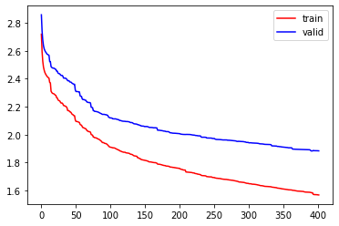

```python
#学習状況の可視化
plt.plot(results_dict["train"]["rmse"], color = "red", label = "train")
plt.plot(results_dict["valid"]["rmse"], color = "blue", label = "valid")
plt.legend()
plt.show()
```

```python
pred_xgb = model_xgb.predict(xgb.DMatrix(X_test))
pred0 = pred_xgb.copy
print(pred_xgb)
```

```
[0.716308   0.39293748 1.5432395  ... 0.05641293 0.05171122 0.17428483]
```

##### ここまでで2019年11月分の売上個数を求めた。この後予測結果（pred_xgb）をtrainデータにconcatし、2019年11月分の売上個数（仮）がある状態で予測させる。流れは大体同じ(追加で店舗規模を特徴量に含める)。

```python
#test2は12月の売上個数を出すために使う部分、testはさっき出した11月分の売上個数（一部商品のみ）
test2 = pd.read_csv('./sales_data/test.csv')
test['quantity'] = pred_xgb
test =test.rename(columns={'quantity': '売上個数'})
test['月ブロック'] = 22
test = test.drop('index', axis=1)
test
```

|  | 商品ID | 店舗ID | 売上個数 | 月ブロック |
| --- | --- | --- | --- | --- |
| 0 | 1000001 | 0 | 0.716308 | 22 |
| 1 | 1000001 | 1 | 0.392937 | 22 |
| 2 | 1000001 | 2 | 1.543239 | 22 |
| 3 | 1000001 | 3 | 1.893158 | 22 |
| 4 | 1000001 | 4 | 6.225881 | 22 |
| ... | ... | ... | ... | ... |
| 3055 | 3500001 | 13 | 1.383956 | 22 |
| 3056 | 3500001 | 14 | 0.040927 | 22 |
| 3057 | 3500001 | 15 | 0.056413 | 22 |
| 3058 | 3500001 | 16 | 0.051711 | 22 |
| 3059 | 3500001 | 17 | 0.174285 | 22 |

3060 rows × 4 columns

```python
# 「年」と「月」の全組み合わせを作成する
gp_time = shistory.groupby(['年', '月']).count().reset_index()[['年', '月']]

# カラム名「月ブロック」として、通し番号をつける
gp_time['月ブロック'] = list(range(len(gp_time)))

# testデータ用に、2019年11,12月(月ブロック: 22,23)のレコードを追加する
gp_time = gp_time.append({
    '月ブロック': 22,
    '年': '2019',
    '月': '11'
}, ignore_index=True)
gp_time = gp_time.append({
    '月ブロック': 23,
    '年': '2019',
    '月': '12'
}, ignore_index=True)
gp_time
```

|  | 年 | 月 | 月ブロック |
| --- | --- | --- | --- |
| 0 | 2018 | 01 | 0 |
| 1 | 2018 | 02 | 1 |
| 2 | 2018 | 03 | 2 |
| 3 | 2018 | 04 | 3 |
| 4 | 2018 | 05 | 4 |
| 5 | 2018 | 06 | 5 |
| 6 | 2018 | 07 | 6 |
| 7 | 2018 | 08 | 7 |
| 8 | 2018 | 09 | 8 |
| 9 | 2018 | 10 | 9 |
| 10 | 2018 | 11 | 10 |
| 11 | 2018 | 12 | 11 |
| 12 | 2019 | 01 | 12 |
| 13 | 2019 | 02 | 13 |
| 14 | 2019 | 03 | 14 |
| 15 | 2019 | 04 | 15 |
| 16 | 2019 | 05 | 16 |
| 17 | 2019 | 06 | 17 |
| 18 | 2019 | 07 | 18 |
| 19 | 2019 | 08 | 19 |
| 20 | 2019 | 09 | 20 |
| 21 | 2019 | 10 | 21 |
| 22 | 2019 | 11 | 22 |
| 23 | 2019 | 12 | 23 |

```python
dataset = pd.concat([all_train, test])
dataset
```

|  | 月ブロック | 商品ID | 店舗ID | 売上個数 |
| --- | --- | --- | --- | --- |
| 0 | 0 | 1000001 | 0 | 6.000000 |
| 1 | 0 | 1000001 | 1 | 2.000000 |
| 2 | 0 | 1000001 | 2 | 1.000000 |
| 3 | 0 | 1000001 | 3 | 2.000000 |
| 4 | 0 | 1000001 | 4 | 0.000000 |
| ... | ... | ... | ... | ... |
| 3055 | 22 | 3500001 | 13 | 1.383956 |
| 3056 | 22 | 3500001 | 14 | 0.040927 |
| 3057 | 22 | 3500001 | 15 | 0.056413 |
| 3058 | 22 | 3500001 | 16 | 0.051711 |
| 3059 | 22 | 3500001 | 17 | 0.174285 |

1650546 rows × 4 columns

```python
#test2に月ブロックを追加
test2['月ブロック'] = 23
test2.drop('index', axis=1, inplace=True)
test2
```

|  | 商品ID | 店舗ID | 月ブロック |
| --- | --- | --- | --- |
| 0 | 1000001 | 0 | 23 |
| 1 | 1000001 | 1 | 23 |
| 2 | 1000001 | 2 | 23 |
| 3 | 1000001 | 3 | 23 |
| 4 | 1000001 | 4 | 23 |
| ... | ... | ... | ... |
| 3055 | 3500001 | 13 | 23 |
| 3056 | 3500001 | 14 | 23 |
| 3057 | 3500001 | 15 | 23 |
| 3058 | 3500001 | 16 | 23 |
| 3059 | 3500001 | 17 | 23 |

3060 rows × 3 columns

```python
dataset = pd.concat([dataset, test2])
dataset
```

|  | 月ブロック | 商品ID | 店舗ID | 売上個数 |
| --- | --- | --- | --- | --- |
| 0 | 0 | 1000001 | 0 | 6.0 |
| 1 | 0 | 1000001 | 1 | 2.0 |
| 2 | 0 | 1000001 | 2 | 1.0 |
| 3 | 0 | 1000001 | 3 | 2.0 |
| 4 | 0 | 1000001 | 4 | 0.0 |
| ... | ... | ... | ... | ... |
| 3055 | 23 | 3500001 | 13 | NaN |
| 3056 | 23 | 3500001 | 14 | NaN |
| 3057 | 23 | 3500001 | 15 | NaN |
| 3058 | 23 | 3500001 | 16 | NaN |
| 3059 | 23 | 3500001 | 17 | NaN |

1653606 rows × 4 columns

```python
#商品カテゴリIDや年、月のカラムを追加
dataset2 = pd.merge(dataset, item_category, on='商品ID', how='left')
dataset2 = pd.merge(dataset2, gp_time, on='月ブロック', how='left')
dataset2['年'] = dataset2['年'].astype(int)
dataset2['月'] = dataset2['月'].astype(int)

print(dataset2.info())
dataset2
```

```
<class 'pandas.core.frame.DataFrame'>
Int64Index: 1653606 entries, 0 to 1653605
Data columns (total 7 columns):
 #   Column    Non-Null Count    Dtype
---  ------    --------------    -----
 0   月ブロック     1653606 non-null  int64
 1   商品ID      1653606 non-null  int64
 2   店舗ID      1653606 non-null  int64
 3   売上個数      1650546 non-null  float64
 4   商品カテゴリID  1653606 non-null  int64
 5   年         1653606 non-null  int32
 6   月         1653606 non-null  int32
dtypes: float64(1), int32(2), int64(4)
memory usage: 88.3 MB
None
```

|  | 月ブロック | 商品ID | 店舗ID | 売上個数 | 商品カテゴリID | 年 | 月 |
| --- | --- | --- | --- | --- | --- | --- | --- |
| 0 | 0 | 1000001 | 0 | 6.0 | 100 | 2018 | 1 |
| 1 | 0 | 1000001 | 1 | 2.0 | 100 | 2018 | 1 |
| 2 | 0 | 1000001 | 2 | 1.0 | 100 | 2018 | 1 |
| 3 | 0 | 1000001 | 3 | 2.0 | 100 | 2018 | 1 |
| 4 | 0 | 1000001 | 4 | 0.0 | 100 | 2018 | 1 |
| ... | ... | ... | ... | ... | ... | ... | ... |
| 1653601 | 23 | 3500001 | 13 | NaN | 350 | 2019 | 12 |
| 1653602 | 23 | 3500001 | 14 | NaN | 350 | 2019 | 12 |
| 1653603 | 23 | 3500001 | 15 | NaN | 350 | 2019 | 12 |
| 1653604 | 23 | 3500001 | 16 | NaN | 350 | 2019 | 12 |
| 1653605 | 23 | 3500001 | 17 | NaN | 350 | 2019 | 12 |

1653606 rows × 7 columns

```python
#特徴量生成
lag1 = dataset.copy()
lag1['月ブロック'] = lag1['月ブロック'] + 1
lag1 = lag1.rename(columns={'売上個数': '1ヶ月前の売上個数'})

lag2 = dataset.copy()
lag2['月ブロック'] = lag2['月ブロック'] + 12
lag2 = lag2.rename(columns={'売上個数': '12ヶ月前の売上個数'})

#特徴量追加
dataset3 = pd.merge(dataset2, lag1, on=['月ブロック', '商品ID', '店舗ID'], how='left', left_index=True)
dataset3 = pd.merge(dataset3, lag2, on=['月ブロック', '商品ID', '店舗ID'], how='left', left_index=True)
print(dataset3.groupby('月ブロック').agg({'1ヶ月前の売上個数': 'count'}))
dataset3
```

```
       1ヶ月前の売上個数
月ブロック
0              0
1          72684
2          73332
3          72540
4          72144
5          71820
6          72432
7          68634
8          67590
9          65592
10         66348
11         68688
12         66528
13         59076
14         58032
15         55044
16         54216
17         53640
18         52362
19         51570
20         48636
21         47178
22          3024
23          3060
```

|  | 月ブロック | 商品ID | 店舗ID | 売上個数 | 商品カテゴリID | 年 | 月 | 1ヶ月前の売上個数 | 12ヶ月前の売上個数 |
| --- | --- | --- | --- | --- | --- | --- | --- | --- | --- |
| NaN | 0 | 1000001 | 0 | 6.0 | 100 | 2018 | 1 | NaN | NaN |
| NaN | 0 | 1000001 | 1 | 2.0 | 100 | 2018 | 1 | NaN | NaN |
| NaN | 0 | 1000001 | 2 | 1.0 | 100 | 2018 | 1 | NaN | NaN |
| NaN | 0 | 1000001 | 3 | 2.0 | 100 | 2018 | 1 | NaN | NaN |
| NaN | 0 | 1000001 | 4 | 0.0 | 100 | 2018 | 1 | NaN | NaN |
| ... | ... | ... | ... | ... | ... | ... | ... | ... | ... |
| 987709.0 | 23 | 3500001 | 13 | NaN | 350 | 2019 | 12 | 1.383956 | 3.0 |
| 987710.0 | 23 | 3500001 | 14 | NaN | 350 | 2019 | 12 | 0.040927 | 0.0 |
| 987711.0 | 23 | 3500001 | 15 | NaN | 350 | 2019 | 12 | 0.056413 | 0.0 |
| 987712.0 | 23 | 3500001 | 16 | NaN | 350 | 2019 | 12 | 0.051711 | 0.0 |
| 987713.0 | 23 | 3500001 | 17 | NaN | 350 | 2019 | 12 | 0.174285 | 1.0 |

1653606 rows × 9 columns

```python
#商品カテゴリ名を追加したい
dataset3 = pd.merge(dataset3, category_name, on=['商品カテゴリID'], how='left')
#商品カテゴリ名は大小に分けてからlabelencodingで数値化。
dataset3['大カテゴリ名'] = dataset3['商品カテゴリ名'].str.split(pat = '-', n = 2 , expand = True)[0]
dataset3['小カテゴリ名']= dataset3['商品カテゴリ名'].str.split(pat = '-', n = 2 , expand = True)[1]

from sklearn.preprocessing import LabelEncoder
lbl = LabelEncoder()
lbl.fit(dataset3['大カテゴリ名'].values)
dataset3['大カテゴリ名'] = lbl.transform(dataset3['大カテゴリ名'].values)
lbl.fit(dataset3['小カテゴリ名'].values)
dataset3['小カテゴリ名'] = lbl.transform(dataset3['小カテゴリ名'].values)

dataset3 = dataset3.drop('商品カテゴリ名', axis=1)
dataset3
```

|  | 月ブロック | 商品ID | 店舗ID | 売上個数 | 商品カテゴリID | 年 | 月 | 1ヶ月前の売上個数 | 12ヶ月前の売上個数 | 大カテゴリ名 | 小カテゴリ名 |
| --- | --- | --- | --- | --- | --- | --- | --- | --- | --- | --- | --- |
| 0 | 0 | 1000001 | 0 | 6.0 | 100 | 2018 | 1 | NaN | NaN | 5 | 1 |
| 1 | 0 | 1000001 | 1 | 2.0 | 100 | 2018 | 1 | NaN | NaN | 5 | 1 |
| 2 | 0 | 1000001 | 2 | 1.0 | 100 | 2018 | 1 | NaN | NaN | 5 | 1 |
| 3 | 0 | 1000001 | 3 | 2.0 | 100 | 2018 | 1 | NaN | NaN | 5 | 1 |
| 4 | 0 | 1000001 | 4 | 0.0 | 100 | 2018 | 1 | NaN | NaN | 5 | 1 |
| ... | ... | ... | ... | ... | ... | ... | ... | ... | ... | ... | ... |
| 1653601 | 23 | 3500001 | 13 | NaN | 350 | 2019 | 12 | 1.383956 | 3.0 | 6 | 6 |
| 1653602 | 23 | 3500001 | 14 | NaN | 350 | 2019 | 12 | 0.040927 | 0.0 | 6 | 6 |
| 1653603 | 23 | 3500001 | 15 | NaN | 350 | 2019 | 12 | 0.056413 | 0.0 | 6 | 6 |
| 1653604 | 23 | 3500001 | 16 | NaN | 350 | 2019 | 12 | 0.051711 | 0.0 | 6 | 6 |
| 1653605 | 23 | 3500001 | 17 | NaN | 350 | 2019 | 12 | 0.174285 | 1.0 | 6 | 6 |

1653606 rows × 11 columns

```python
data_na = (dataset3.isnull().sum())
data_na
```

```
月ブロック               0
商品ID                0
店舗ID                0
売上個数             3060
商品カテゴリID            0
年                   0
月                   0
1ヶ月前の売上個数      329436
12ヶ月前の売上個数    1278324
大カテゴリ名              0
小カテゴリ名              0
dtype: int64
```

```python
dataset4 = dataset3.drop(['商品カテゴリID'] , axis=1)
print(dataset4)
#columnの並べ替え
dataset4 = dataset4.reindex(columns=['月ブロック', '年', '月', '店舗ID', '商品ID', '大カテゴリ名', '小カテゴリ名',
                                     '1ヶ月前の売上個数','12ヶ月前の売上個数', '売上個数'])
dataset4 =dataset4.rename(columns={'月ブロック': 'monthb','年': 'year', '月': 'month', '店舗ID': 'store_id', '商品ID': 'item_id',
                                   '大カテゴリ名': 'big_cat', '小カテゴリ名': 'small_cat', '1ヶ月前の売上個数': 'quantity_1-ago',
                                   '12ヶ月前の売上個数': 'quantity_12-ago','売上個数': 'quantity'})
dataset4 = dataset4.reset_index(drop=True)
dataset4
```

```
         月ブロック     商品ID  店舗ID  売上個数     年   月  1ヶ月前の売上個数  12ヶ月前の売上個数  大カテゴリ名  \
0            0  1000001     0   6.0  2018   1        NaN         NaN       5
1            0  1000001     1   2.0  2018   1        NaN         NaN       5
2            0  1000001     2   1.0  2018   1        NaN         NaN       5
3            0  1000001     3   2.0  2018   1        NaN         NaN       5
4            0  1000001     4   0.0  2018   1        NaN         NaN       5
...        ...      ...   ...   ...   ...  ..        ...         ...     ...
1653601     23  3500001    13   NaN  2019  12   1.383956         3.0       6
1653602     23  3500001    14   NaN  2019  12   0.040927         0.0       6
1653603     23  3500001    15   NaN  2019  12   0.056413         0.0       6
1653604     23  3500001    16   NaN  2019  12   0.051711         0.0       6
1653605     23  3500001    17   NaN  2019  12   0.174285         1.0       6

         小カテゴリ名
0             1
1             1
2             1
3             1
4             1
...         ...
1653601       6
1653602       6
1653603       6
1653604       6
1653605       6

[1653606 rows x 10 columns]
```

|  | monthb | year | month | store_id | item_id | big_cat | small_cat | quantity_1-ago | quantity_12-ago | quantity |
| --- | --- | --- | --- | --- | --- | --- | --- | --- | --- | --- |
| 0 | 0 | 2018 | 1 | 0 | 1000001 | 5 | 1 | NaN | NaN | 6.0 |
| 1 | 0 | 2018 | 1 | 1 | 1000001 | 5 | 1 | NaN | NaN | 2.0 |
| 2 | 0 | 2018 | 1 | 2 | 1000001 | 5 | 1 | NaN | NaN | 1.0 |
| 3 | 0 | 2018 | 1 | 3 | 1000001 | 5 | 1 | NaN | NaN | 2.0 |
| 4 | 0 | 2018 | 1 | 4 | 1000001 | 5 | 1 | NaN | NaN | 0.0 |
| ... | ... | ... | ... | ... | ... | ... | ... | ... | ... | ... |
| 1653601 | 23 | 2019 | 12 | 13 | 3500001 | 6 | 6 | 1.383956 | 3.0 | NaN |
| 1653602 | 23 | 2019 | 12 | 14 | 3500001 | 6 | 6 | 0.040927 | 0.0 | NaN |
| 1653603 | 23 | 2019 | 12 | 15 | 3500001 | 6 | 6 | 0.056413 | 0.0 | NaN |
| 1653604 | 23 | 2019 | 12 | 16 | 3500001 | 6 | 6 | 0.051711 | 0.0 | NaN |
| 1653605 | 23 | 2019 | 12 | 17 | 3500001 | 6 | 6 | 0.174285 | 1.0 | NaN |

1653606 rows × 10 columns

```python
#「店舗規模」の特徴量を作る
shistory = pd.read_csv('./sales_data/sales_history.csv')
#商品価格が一定値以上の行を削除
shistory = shistory[shistory.商品価格<20000]
shistory = shistory[shistory.商品価格!=0]
shistory

#各店舗の売り上げ状況から店舗規模を出す
from sklearn.preprocessing import MinMaxScaler
shistory['売り上げ']=shistory['商品価格'] * shistory['売上個数']
df_uriage = shistory[['店舗ID','売り上げ']]
df_uriage2 = df_uriage.groupby(['店舗ID']).sum()
#正規化のクラスを準備　x=(x-x.min)/(x.max-x.min) によって0~1にする
ms = MinMaxScaler()
#特徴量の最大値と最小値を計算し変換
data_sc = ms.fit_transform(df_uriage2)
df_uriage2['店舗規模'] = data_sc
df_uriage2 = df_uriage2.reset_index()
df_uriage3 = df_uriage2[['店舗ID','店舗規模']]
df_uriage3

#店舗規模をデータに組み込む
df_uriage3 = df_uriage3.rename(columns={'店舗ID': 'store_id', '店舗規模': 'store_scale'})
dataset4 = pd.merge(dataset4, df_uriage3, on=['store_id'], how='left')
dataset4 = dataset4.reindex(columns=['monthb', 'year', 'month', 'store_id', 'store_scale', 'item_id', 'big_cat', 'small_cat',
                                     'quantity_1-ago', 'quantity_12-ago', 'quantity'])
dataset4
```

|  | monthb | year | month | store_id | store_scale | item_id | big_cat | small_cat | quantity_1-ago | quantity_12-ago | quantity |
| --- | --- | --- | --- | --- | --- | --- | --- | --- | --- | --- | --- |
| 0 | 0 | 2018 | 1 | 0 | 0.759685 | 1000001 | 5 | 1 | NaN | NaN | 6.0 |
| 1 | 0 | 2018 | 1 | 1 | 0.054496 | 1000001 | 5 | 1 | NaN | NaN | 2.0 |
| 2 | 0 | 2018 | 1 | 2 | 0.228441 | 1000001 | 5 | 1 | NaN | NaN | 1.0 |
| 3 | 0 | 2018 | 1 | 3 | 0.461096 | 1000001 | 5 | 1 | NaN | NaN | 2.0 |
| 4 | 0 | 2018 | 1 | 4 | 0.278063 | 1000001 | 5 | 1 | NaN | NaN | 0.0 |
| ... | ... | ... | ... | ... | ... | ... | ... | ... | ... | ... | ... |
| 1653601 | 23 | 2019 | 12 | 13 | 0.746409 | 3500001 | 6 | 6 | 1.383956 | 3.0 | NaN |
| 1653602 | 23 | 2019 | 12 | 14 | 0.178779 | 3500001 | 6 | 6 | 0.040927 | 0.0 | NaN |
| 1653603 | 23 | 2019 | 12 | 15 | 0.009137 | 3500001 | 6 | 6 | 0.056413 | 0.0 | NaN |
| 1653604 | 23 | 2019 | 12 | 16 | 0.000000 | 3500001 | 6 | 6 | 0.051711 | 0.0 | NaN |
| 1653605 | 23 | 2019 | 12 | 17 | 0.216281 | 3500001 | 6 | 6 | 0.174285 | 1.0 | NaN |

1653606 rows × 11 columns

```python
# 学習のためのデータ分割
train_dataset = dataset4[(dataset4['monthb'] >= 0) & (dataset4['monthb'] != 23)]
test_dataset = dataset4[dataset4['monthb'] == 23]

#学習、テストデータに分割
X_train = train_dataset.drop('monthb', axis=1)
y_train = train_dataset['quantity']
X_test = test_dataset.drop(['monthb','quantity'], axis=1)

X_test
```

|  | year | month | store_id | store_scale | item_id | big_cat | small_cat | quantity_1-ago | quantity_12-ago |
| --- | --- | --- | --- | --- | --- | --- | --- | --- | --- |
| 1650546 | 2019 | 12 | 0 | 0.759685 | 1000001 | 5 | 1 | 0.716308 | 0.0 |
| 1650547 | 2019 | 12 | 1 | 0.054496 | 1000001 | 5 | 1 | 0.392937 | 0.0 |
| 1650548 | 2019 | 12 | 2 | 0.228441 | 1000001 | 5 | 1 | 1.543239 | 0.0 |
| 1650549 | 2019 | 12 | 3 | 0.461096 | 1000001 | 5 | 1 | 1.893158 | 9.0 |
| 1650550 | 2019 | 12 | 4 | 0.278063 | 1000001 | 5 | 1 | 6.225881 | 7.0 |
| ... | ... | ... | ... | ... | ... | ... | ... | ... | ... |
| 1653601 | 2019 | 12 | 13 | 0.746409 | 3500001 | 6 | 6 | 1.383956 | 3.0 |
| 1653602 | 2019 | 12 | 14 | 0.178779 | 3500001 | 6 | 6 | 0.040927 | 0.0 |
| 1653603 | 2019 | 12 | 15 | 0.009137 | 3500001 | 6 | 6 | 0.056413 | 0.0 |
| 1653604 | 2019 | 12 | 16 | 0.000000 | 3500001 | 6 | 6 | 0.051711 | 0.0 |
| 1653605 | 2019 | 12 | 17 | 0.216281 | 3500001 | 6 | 6 | 0.174285 | 1.0 |

3060 rows × 9 columns

```python
#データ分割
from sklearn.model_selection import KFold
kf = KFold(n_splits = 5, shuffle = True, random_state=42)
X_train["fold"] = -1
for fold, (train_idx, valid_idx) in enumerate(kf.split(X_train)):
    X_train.loc[valid_idx, "fold"] = fold
print(X_train["fold"].value_counts())

fold = 0
train = X_train.loc[X_train["fold"] != fold].copy()
valid = X_train.loc[X_train["fold"] == fold].copy()
print(train.shape, valid.shape)

feat_cols = train.drop(columns = ["fold", "quantity"]).columns.tolist()
print(feat_cols)

X_train = train[feat_cols]
X_valid = valid[feat_cols]
y_train = train["quantity"]
y_valid = valid["quantity"]

dtrain = xgb.DMatrix(X_train, y_train)
dvalid = xgb.DMatrix(X_valid, y_valid)

params = {
    "objective" : "reg:squarederror",
    "eval_metric" : "rmse",
}

results_dict = {}
model_xgb = xgb.train(
    params = params,
    dtrain = dtrain,
    evals = [(dtrain, "train"), (dvalid, "valid")],
    num_boost_round = 1000,
    early_stopping_rounds = 10,
    evals_result = results_dict
)
```

```
0    330110
4    330109
3    330109
2    330109
1    330109
Name: fold, dtype: int64
(1320436, 11) (330110, 11)
['year', 'month', 'store_id', 'store_scale', 'item_id', 'big_cat', 'small_cat', 'quantity_1-ago', 'quantity_12-ago']
```

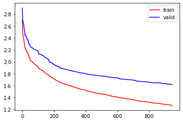

```python
#学習状況の可視化
plt.plot(results_dict["train"]["rmse"], color = "red", label = "train")
plt.plot(results_dict["valid"]["rmse"], color = "blue", label = "valid")
plt.legend()
plt.show()
```

```python
pred_xgb2 = model_xgb.predict(xgb.DMatrix(X_test))
#予測結果が0未満だったものは0にする
pred_xgb2[pred_xgb2 < 0] = 0
print(pred_xgb2)
```

```
[0.         0.26995805 1.2772697  ... 0.06755307 0.09614512 0.24020228]
```

```python
#他の学習機にも学習させるために再度データ分割を行う
train_dataset = dataset4[(dataset4['monthb'] >= 0) & (dataset4['monthb'] != 23)]
test_dataset = dataset4[dataset4['monthb'] == 23]

X_train = train_dataset.drop('monthb', axis=1)
y_train = train_dataset['quantity']
X_test = test_dataset.drop(['monthb','quantity'], axis=1)

X_test
```

|  | year | month | store_id | store_scale | item_id | big_cat | small_cat | quantity_1-ago | quantity_12-ago |
| --- | --- | --- | --- | --- | --- | --- | --- | --- | --- |
| 1650546 | 2019 | 12 | 0 | 0.759685 | 1000001 | 5 | 1 | 0.716308 | 0.0 |
| 1650547 | 2019 | 12 | 1 | 0.054496 | 1000001 | 5 | 1 | 0.392937 | 0.0 |
| 1650548 | 2019 | 12 | 2 | 0.228441 | 1000001 | 5 | 1 | 1.543239 | 0.0 |
| 1650549 | 2019 | 12 | 3 | 0.461096 | 1000001 | 5 | 1 | 1.893158 | 9.0 |
| 1650550 | 2019 | 12 | 4 | 0.278063 | 1000001 | 5 | 1 | 6.225881 | 7.0 |
| ... | ... | ... | ... | ... | ... | ... | ... | ... | ... |
| 1653601 | 2019 | 12 | 13 | 0.746409 | 3500001 | 6 | 6 | 1.383956 | 3.0 |
| 1653602 | 2019 | 12 | 14 | 0.178779 | 3500001 | 6 | 6 | 0.040927 | 0.0 |
| 1653603 | 2019 | 12 | 15 | 0.009137 | 3500001 | 6 | 6 | 0.056413 | 0.0 |
| 1653604 | 2019 | 12 | 16 | 0.000000 | 3500001 | 6 | 6 | 0.051711 | 0.0 |
| 1653605 | 2019 | 12 | 17 | 0.216281 | 3500001 | 6 | 6 | 0.174285 | 1.0 |

3060 rows × 9 columns

```python
import time
ts = time.time()

from sklearn.model_selection import KFold
kf = KFold(n_splits = 5, shuffle = True, random_state=42)
X_train["fold"] = -1
for fold, (train_idx, valid_idx) in enumerate(kf.split(X_train)):
    X_train.loc[valid_idx, "fold"] = fold
print(X_train["fold"].value_counts())

fold = 0
train = X_train.loc[X_train["fold"] != fold].copy()
valid = X_train.loc[X_train["fold"] == fold].copy()
print(train.shape, valid.shape)

feat_cols = train.drop(columns = ["fold", "quantity"]).columns.tolist()
print(feat_cols)

X_train = train[feat_cols]
X_valid = valid[feat_cols]
y_train = train["quantity"]
y_valid = valid["quantity"]

from xgboost import XGBRegressor
xgbr = XGBRegressor(
    n_estimators=1000,
    seed=42)

xgbr.fit(
    X_train,
    y_train,
    eval_metric="rmse",
    eval_set=[(X_train, y_train), (X_valid, y_valid)],
    verbose=True,
    early_stopping_rounds = 10)

time.time() - ts
```

```
0    330110
4    330109
3    330109
2    330109
1    330109
Name: fold, dtype: int64
(1320436, 11) (330110, 11)
['year', 'month', 'store_id', 'store_scale', 'item_id', 'big_cat', 'small_cat', 'quantity_1-ago', 'quantity_12-ago']
```

```
461.62584137916565
```

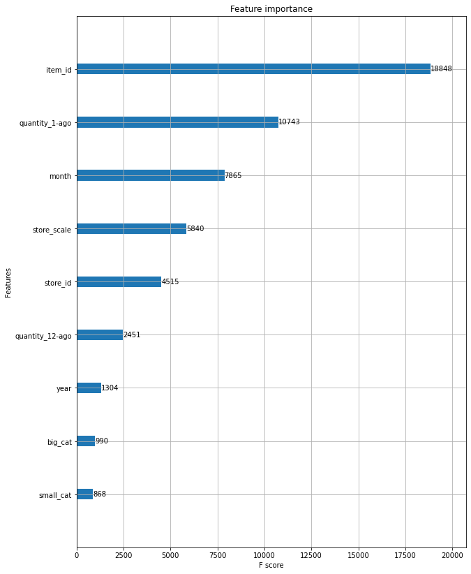

```python
#feature importanceを確認
from xgboost import plot_importance
def plot_features(booster, figsize):
    fig, ax = plt.subplots(1,1,figsize=figsize)
    return plot_importance(booster=booster, ax=ax)

plot_features(xgbr, (10,14))
```

```python
pred_xgbr1 = xgbr.predict(X_test)
#予測結果が0未満だったものは0にする
pred_xgbr1[pred_xgbr1 < 0] = 0
print(pred_xgbr1)
```

```
[0.         0.25083664 1.2810282  ... 0.06632134 0.09491339 0.23897055]
```

```python
#2つの予測結果の平均をとる
pred_ave = (pred_xgb2 + pred_xgbr1)/2
pred_ave
```

```
array([0.        , 0.26039734, 1.2791489 , ..., 0.0669372 , 0.09552925,
       0.23958641], dtype=float32)
```

```python
# 指定の形式で結果のcsvファイルを作成
import pandas as pd
pred_ave = pd.DataFrame(pred_ave)
pred_ave.to_csv('./submit_csv_files/check.csv', header=None)
```